# Pre-existing Samples in cost-constrained cLHS with the *clhs* package

Andrew Brown

February 9, 2019

First, you should understand the concepts in the **Original Demo by Dave White:** http://ncss-tech.github.io/stats_for_soil_survey/presentations/examples/clhs.html

# Concepts

## Basics

The basic premise of the *pre-existing data* extension to *cost-constrained* Conditioned Latin Hypercube Sampling is that you can “force” a `clhs::clhs()` routine include an arbitrary set of (user-defined) samples *in your final result*. That is, the set of points that it has when the number of iterations set by the user is reached.

This replaces samples selected by the cost-cLHS algorithm – *an equal amount to the number of existing points you have*. Be aware of this when setting `size` argument of `clhs()`

These “forced” data come at “zero-cost” because, well (at least theoretically) you *already have them*. In theory, this *very-low-cost* partially counteracts the fact that pre-existing locations are not likely to span the environmental variable space (rasters).

Samples can be biased in terms of the number of observations from certain kinds of areas, causing their influence to be over-represented in aggregate.

## This Demo

This demo uses the demonstration dataset prepared by Dave White.

To simulate “existing data” a set of random samples is collected from the non-NA extent of the *RasterStack*. These are hypothetical “pre-existing data”.

Even though random samples are truly “unbiased” – a small number of random samples are less likely to consistently span the full range of the multivariate data space (the RasterStack) when compared to a much larger sample, or exhaustive, approach to sampling.

The *RasterStack* is regularly sampled (“exhaustively”; n=10,000) and these regular samples are passed to the cLHS algorithm for optimization to the user defined number of samples. If you are using very small cell resolutions or large rasters, you will need to adjust the number of exhaustive samples you take.

The first three cLHS routines are run using the cost raster `r.cost`, and the fourth by the classic method. `s` is default cost cLHS, `s.with.existing` is set up to retain the random samples in the last “set” of points cLHS algorithm evaluates, `s.with.cheap` uses biased existing samples and `s.classic` is the Classic cLHS set of points. Also, tabular results for “Exhaustive” sampling (regular grid) and “Population” (whole RasterStack) are included.

These observations are appended to the begining of the `all.observations` SpatialPointsDataFrame and indexed using a numeric index `1:n.existing`. The ordering and index choice is important. Note the addition of the `include` argument to the `clhs()` call that makes `s.with.existing` and `s.with.cheap`.

The final result plot shows the location of cost-constrained cLHS, with and without pre-existing samples on top of the cost raster

**WARNING:** Use this routine your own risk. The addition to the cLHS algorithm is new and may potentially have unintended effects on clhs result. This addition was just made to the latest official release of `clhs` (was published to CRAN mid-October 2018)

# Sample Code

## Load data into RasterStack

Get the data if you need it.

```r
# create a new directory to store the data
dir.create("C:/workspace2/clhs", recursive = TRUE)

# setting the working directory
setwd("C:/workspace2/clhs/")

# download data
download.file(url = "http://github.com/dave-white2/data/raw/master/clhs/clhs_data.zip", destfile = "clhs.zip", method = "auto")

# unzip data
unzip(zipfile = "C:/workspace2/clhs/clhs.zip", overwrite = TRUE)
```

```r
library(rgdal)
library(raster)
library(clhs)

setwd("C:/workspace2/clhs/")

# load raster data of same extent and resolution
r.claymin <- raster("claymin.tif")
r.mrrtf <- raster("mrrtf.tif")
r.mrvbf <- raster("mrvbf.tif")
r.ndvi <- raster("ndvi.tif")
r.sagawi <- raster("sagawi.tif")
r.cost <- raster("cost.tif")

r.stack.cost <- stack(r.claymin,  r.mrvbf, r.ndvi, r.sagawi, r.cost)
names(r.stack.cost) <- c('claymin',  'mrvbf', 'ndvi', 'sagawi', 'cost')

# r.stack.cost <- stack(r.claymin, r.mrrtf, r.mrvbf, r.ndvi, r.sagawi, r.cost)
# names(r.stack.cost) <- c('claymin', 'mrrtf', 'mrvbf', 'ndvi', 'sagawi', 'cost')

r.stack.cost <- readAll(r.stack.cost)

r.extent.poly <- as(extent(r.stack.cost), "SpatialPolygons")

proj4string(r.extent.poly) <- proj4string(r.stack.cost)
```

## Pre-existing data

Make up some hypothetical “existing observation” locations.

```r
# how many existing sample locations to simulate?
n.existing <- 10

# an equal number of cLHS samples will be generated for pre-existing
# data runs of clhs() -- i.e. total points for all cLHS runs returned is n.existing*2

# number of cCLHS iterations
n.iter <- 10000
```

We will compare two methods.

The first method we will take a small Simple Random sample.

Then we will take a biased sample that is likely more realistic for pre-existing data.

To do this we take a large random sample, and *order it based on cost*. Then from that large sample, we take a stratified subsample – selected from the *cheaper half of the large random sample*.

These hoops we jump through force the pre-existing data to have somewhat *lower cost* than is typically obtained from a small Simple Random sample.

Of course, in practice, bias is present. It is not generally intentional. It arises through real operational constraints as well as personal (sometimes well-informed) biases about good places to sample and/or places that need to be sampled.

cLHS only gets a raster-based view of the variablity in the landscape. It may well be that it alone cannot capture all that is “important” about a landscape.

```r
# "existing data" that are truly random
# we set na.rm = TRUE so our "observations" are not in `NA` raster space
obs.existing <- sampleRandom(r.stack.cost, size = n.existing, sp=TRUE, na.rm=TRUE)

# "realistic" existing data have bias - make `obs.existing.cheap` to simulate
# we use the cost raster to bias a subsample of a random sample
obs.rnd <- sampleRandom(r.stack.cost, size = n.existing*10, sp=TRUE, na.rm=TRUE)
obs.rnd <- obs.rnd[order(obs.rnd$cost),]
biased.locations.idx <- floor(runif(n.existing, 1, length(obs.rnd$cost) / 2))
obs.existing.cheap <- obs.rnd[biased.locations.idx,]
```

## Subsample the RasterStack

Use regular sampling to lower the number of cells (see `raster::ncell()`) we are plugging into `clhs()` algorithm.

```r
# use regular sampling to lower the number of cells
reg.samples <- sampleRegular(r.stack.cost, size = n.iter, sp = TRUE)
```

## Match Coordinate Reference System

Here we transform (“project”) our existing data – to ensure match the CRS of the regularly spaced subsample. We will be combining these two spatial objects for the second part of `clhs()`.

```r
obs.existing <- spTransform(obs.existing, CRS(proj4string(reg.samples)))
obs.existing.cheap <- spTransform(obs.existing.cheap, CRS(proj4string(reg.samples)))
```

Combine existing data with regular (sub)sample.

```r
all.observations <- rbind(obs.existing, reg.samples)
all.observations.cheap <- rbind(obs.existing.cheap, reg.samples)
```

Remove any records that may have `NA` cost, pending a fix in *clhs* package.

```r
# pending a fix in clhs package (https://github.com/pierreroudier/clhs/issues/3)
# NA cost values must be filtered from the samples
reg.samples <- reg.samples[which(!is.na(reg.samples$cost)), ]
all.observations <- all.observations[which(!is.na(all.observations$cost)), ]
all.observations.cheap <- all.observations.cheap[which(!is.na(all.observations.cheap$cost)), ]
```

## Cost-constrained c-cLHS

Do the normal cost-constrained cLHS sampling. Same number as the existing points.

```r
s <- clhs(reg.samples,
          size = n.existing*2,
          iter = n.iter,
          cost = 'cost',
          simple = FALSE,
          progress = FALSE)
```

Now the cost-constrained cLHS but force-include the first 10 row-indexes that correspond to our existing data (that we appended to the *beginning* of `all.observations`)

```r
idx.to.include <-1:nrow(obs.existing)

# note we use this numeric vector of indexes later in the proof of concept
idx.to.include
```

```
##  [1]  1  2  3  4  5  6  7  8  9 10
```

```r
s.with.existing <- clhs(all.observations,
                        size = n.existing*2,
                        iter = n.iter,
                        cost = 'cost',
                        include = idx.to.include,
                        simple = FALSE,
                        progress = FALSE)

s.with.cheap <- clhs(all.observations.cheap,
                        size = n.existing*2,
                        iter = n.iter,
                        cost = 'cost',
                        include = idx.to.include,
                        simple = FALSE,
                        progress = FALSE)
```

## Classic cLHS

For a the purposes of full comparison of methods, we will also sample using *Classic* cLHS (without cost constraints). *These samples still have a theoretical “cost”* – it is just not considered in the optimization.

The Classic cLHS is important because we can see where the optimal samples would be placed *if cost were no issue*. This is the “ideal” representation.

```r
s.classic <- clhs(reg.samples,
                   size = n.existing*2,
                   iter = n.iter,
                   simple = FALSE,
                   progress = FALSE)
```

## Diagnostic plots

*cLHS_object* diagnostic plot for normal c-cLHS. This is a custom plotting function for the result obtained when the `clhs()` `simple` argument is `FALSE`. Note that “init” refers to the source distribution and “spl” refers to the sampled distribution.

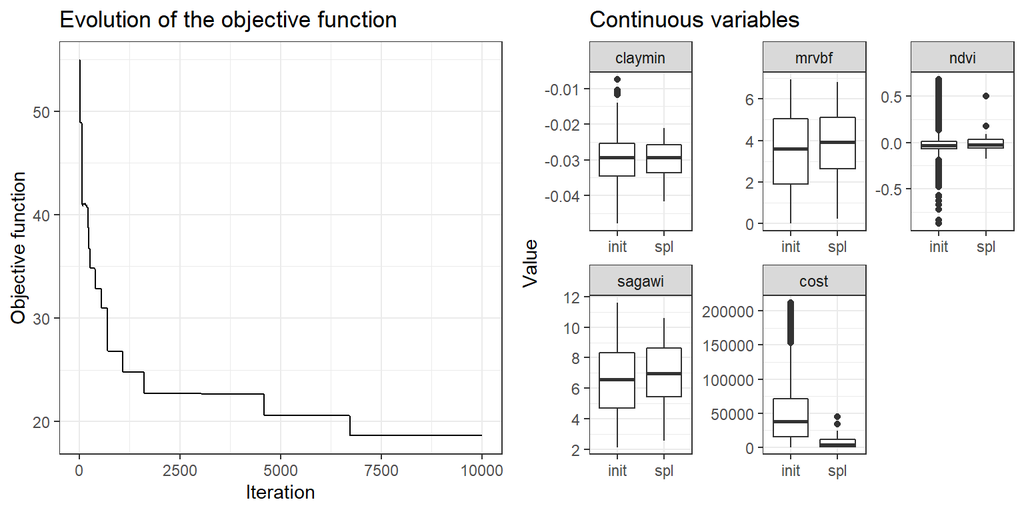

```r
plot(s, mode = c("obj", "box"))
```

And… a diagnostic plot for c-cLHS *with existing data*.

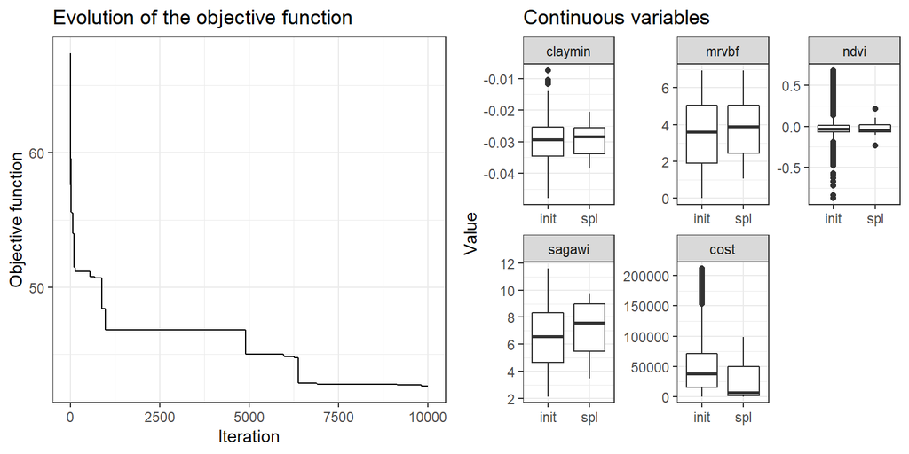

```r
plot(s.with.existing, mode = c("obj", "box"))
```

For the “cheap” *existing data*…

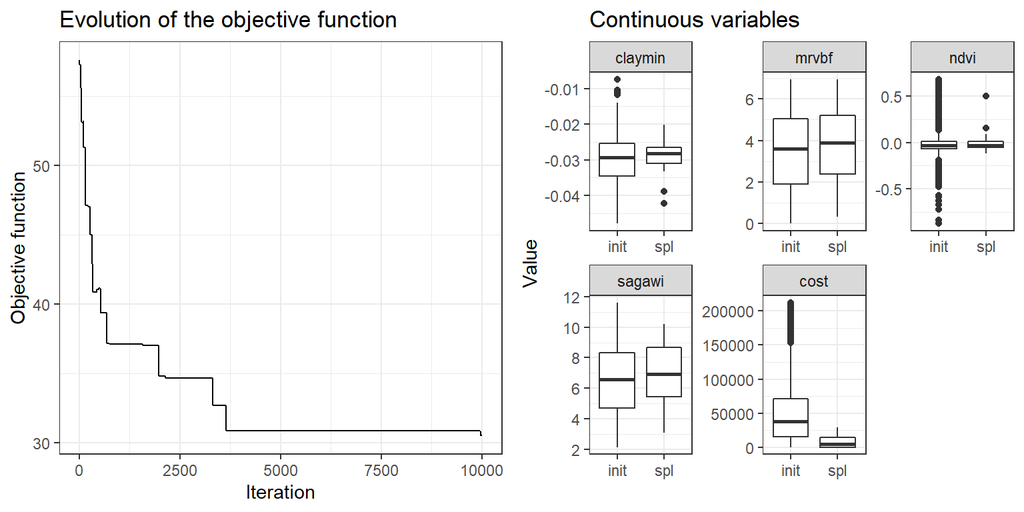

```r
plot(s.with.cheap, mode = c("obj", "box"))
```

Finally, ol’ reliable…

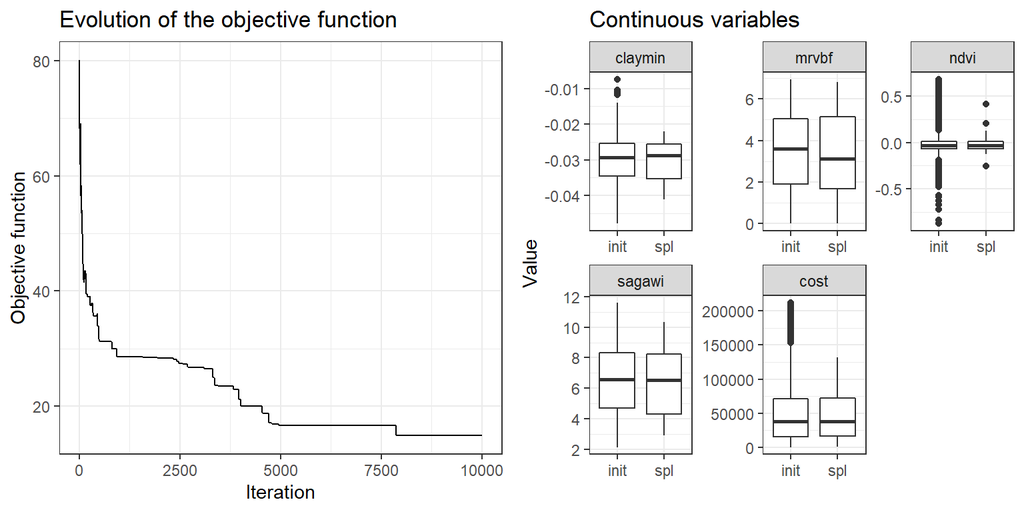

```r
plot(s.classic, mode = c("obj", "box"))
```

## Spatial comparison of Methods

Create numeric vectors containing indices of the samples selected by the cost-constrained cCLHS runs and the two sets of existing samples.

```r
samples.idx <- s$index_samples
existing.idx <- s.with.existing$index_samples
cheap.idx <- s.with.cheap$index_samples
classic.idx <- s.classic$index_samples
```

Make a plot to show where the cLHS samples are located by the three methods (c-CLHS, c-CLHS with Simple Random pre-existing, c-CLHS with “biased” pre-existing).

Plot on an environmental variable (*SAGA Wetness Index*) and cost raster contours as a backdrop.

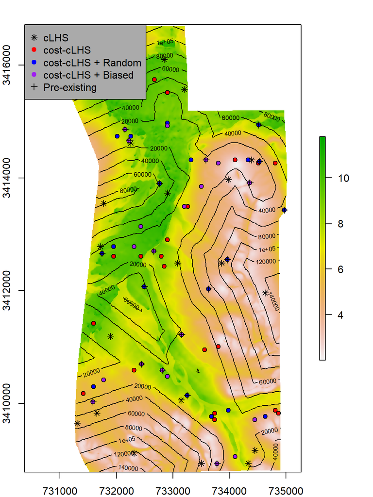

```r
# check point locations visually (on the sagawi raster)
par(mar = c(2,2,2,2))

plot(r.sagawi)
contour(r.cost, nlevels=10, col='black', add=TRUE)

 # plot the regularly-spaced samples that were selected by classic & cost cLHS
points(reg.samples[classic.idx, ], bg = 'black', pch=8)
points(reg.samples[samples.idx, ], bg = 'red', pch=21)

# plot the regularly-spaced samples that were selected when set to retain
# the existing points that were randomly sampled before running clhs
points(reg.samples[samples.idx, ], bg = 'red', pch=21)
points(all.observations[existing.idx, ], bg = 'blue', pch=21)
points(all.observations.cheap[cheap.idx, ], bg = 'purple', pch=21)

# overplot with crosshairs to show existing points (less colors)
points(obs.existing,  pch=3)
points(obs.existing.cheap, pch=3)

legend(x="topleft",
       legend = c("cLHS","cost-cLHS","cost-cLHS + Random","cost-cLHS + Biased","Pre-existing"),
       pch=c(8,19,19,19,3), col=c("black","red","blue","purple","black"), bg="#AAAAAA")
```

Plot the same point groups for comparison on Cost Raster itself.

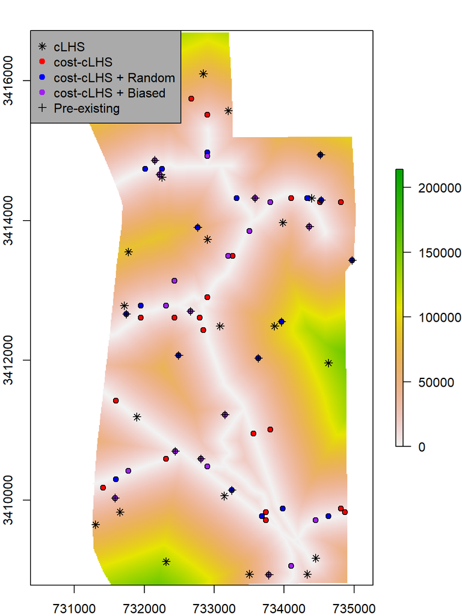

```r
par(mar = c(2, 2, 2, 2))

plot(r.cost)

points(reg.samples[classic.idx, ], bg = 'black', pch=8)
points(reg.samples[samples.idx, ], bg = 'red', pch=21)
points(all.observations[existing.idx, ], bg = 'blue', pch=21)
points(all.observations.cheap[cheap.idx, ], bg = 'purple', pch=21)

# overplot with crosshairs to show existing points (less colors)
points(obs.existing,  pch=3)
points(obs.existing.cheap, pch=3)

legend(x="topleft",
       legend = c("cLHS","cost-cLHS","cost-cLHS + Random","cost-cLHS + Biased","Pre-existing"),
       pch=c(8,19,19,19,3), col=c("black","red","blue","purple","black"), bg="#AAAAAA")
```

Overall, it appears that the randomly sampled existing points occur at much higher cost postitions than the vast majority of the c-cLHS points and the “cost-biased” existing points.

# Proof of Concept

## Combining results for comparison

```r
s.all <- rbind(data.frame(method = "cost-cLHS", s$sampled_data@data),
              data.frame(method = "cost-cLHS + Random", s.with.existing$sampled_data@data),
              data.frame(method = "Random Existing", all.observations[idx.to.include, ]@data),
              data.frame(method = "cost-cLHS + Cheap", s.with.cheap$sampled_data@data),
              data.frame(method = "Cheap Existing", all.observations.cheap[idx.to.include,]@data),
              data.frame(method = "Classic cLHS", s.classic$sampled_data@data),
              data.frame(method = "Exhaustive", reg.samples@data))
s.all$method <- as.character(s.all$method)
```

```r
#TODO
library(lattice)

plot(densityplot( ~ value | variable+method, layout=c(4,6),
               data = s.all.long,
               auto.key = list(corner = c(0.95, 0.95)),
               scales = list(alternating=3),
               strip = strip.custom(bg=grey(0.85))))
```

[output not shown]

```r
# calculate medians for each method X variable combinations
d.mu.wide.no.cost <- dcast(s.all.long[s.all.long$variable != "cost",],
                   method ~ variable,
                   value.var = 'value',
                   fun = median, na.rm=TRUE)

# and sum for cost of all samples in group
d.mu.wide.just.cost <- dcast(s.all.long[s.all.long$variable == "cost",],
                   method ~ variable,
                   value.var = 'value',
                   fun=sum, na.rm=TRUE)

# THE EXISTING SAMPLES COME AT NO COST (WE HAVE THEM)
# make a column for additional cost (of the cLHS on topo of the free existing)
d.mu.wide.just.cost[,3] <- d.mu.wide.just.cost[,2]

# cheap existing - calculate additional cost for cLHS sample
d.mu.wide.just.cost[4,3] <- d.mu.wide.just.cost[4,2] - d.mu.wide.just.cost[1,2]
d.mu.wide.just.cost[1,3] <- 0

# random existing - calculate additional cost for cLHS sample
d.mu.wide.just.cost[5,3] <- d.mu.wide.just.cost[5,2] - d.mu.wide.just.cost[nrow(d.mu.wide.just.cost),3]
d.mu.wide.just.cost[nrow(d.mu.wide.just.cost),3] <- 0

total.cost <- d.mu.wide.just.cost[,2:3]
d.mu.wide <- cbind(d.mu.wide.no.cost, total.cost)
ncol <- length(names(d.mu.wide))
rownames(d.mu.wide) <- 1:nrow(d.mu.wide)
names(d.mu.wide) <- c(names(d.mu.wide.no.cost), c("total.cost", "additional.cost"))

d.mu.wide <- d.mu.wide[order(d.mu.wide[,ncol], d.mu.wide[,ncol-1]),]
```

As you can see below, the median values obtained from the different methods are quite similar. The cost is calculated as the sum of the costs for all the points in the group. Additional cost excludes the cost of existing samples.

Comparison of Sample Medians Obtained by Different cLHS Sampling Methods

| method | claymin | mrvbf | ndvi | sagawi | total.cost | additional.cost | n.obs |
| --- | --- | --- | --- | --- | --- | --- | --- |
| Cheap Existing | -0.0289 | 3.6764 | -0.0386 | 7.0567 | 1.265776e+05 | 0.000000e+00 | 10 |
| Random Existing | -0.0294 | 3.8851 | -0.0418 | 8.3769 | 4.781600e+05 | 0.000000e+00 | 10 |
| cost-cLHS + Random | -0.0283 | 3.9042 | -0.0418 | 7.5669 | 5.013961e+05 | 2.323607e+04 | 20 |
| cost-cLHS + Cheap | -0.0282 | 3.9054 | -0.0311 | 6.9479 | 1.664093e+05 | 3.983169e+04 | 20 |
| cost-cLHS | -0.0292 | 3.9211 | -0.0266 | 6.9826 | 1.837079e+05 | 1.837079e+05 | 20 |
| Classic cLHS | -0.0288 | 3.1173 | -0.0331 | 6.5429 | 9.347962e+05 | 9.347962e+05 | 20 |
| Exhaustive | -0.0293 | 3.5950 | -0.0332 | 6.5697 | 3.521132e+08 | 3.521132e+08 | 7292 |
| Population | -0.0292 | 3.6074 | -0.0327 | 6.5850 | 1.230293e+10 | 1.230293e+10 | 349713 |

Both of the small “Existing” samples appear to exhibit some sort of bias relative to the Classic cLHS, Exhaustive asnd Population values. All cost-cLHS methods have a lower additional cost than Classic cLHS, but Classic cLHS is the closest to the Exhaustive and “Population” values.

Indeed, the Classic cLHS values may be more reflective of the areal abundance of some of the different variations we see in the raster space of this dataset. The Exhaustive values may be affected by the shape of the raster (non-`NA`) relative to the requested density of sampling. The “Population”, similarly, is just a clipped out sample extent from a larger extent stack of rasters.

This “high cost” for a pre-existing dataset might not be a *realistic*. Operational limitations or personal choices would typically have some sort of bias effect on sampling (at least *relative* to true Simple Random Sampling).

To counteract, or at least estimate, possible cases of this effect — we produced a biased set of points using the cost raster as well as some random-ness.

These biased samples show bias to certain parts of the raster space as reflected in their medians. They have a lower additional cost than a full sample set produced using cost-cLHS, but as a result they incur some bias. Comparing the values of the individual existing datasets with their corresponding cLHS group shows that the bias present in the original sample is still reflected, but to a smaller degree (i.e. direction greater or less than population/exhaustive).

## Visualizing differences between cLHS methods with nMDS

We will use *non-metric multidimensional scaling* (nMDS) to visualize any *potential* multivariate differences between the “optimal” samples obtained by the different methods.

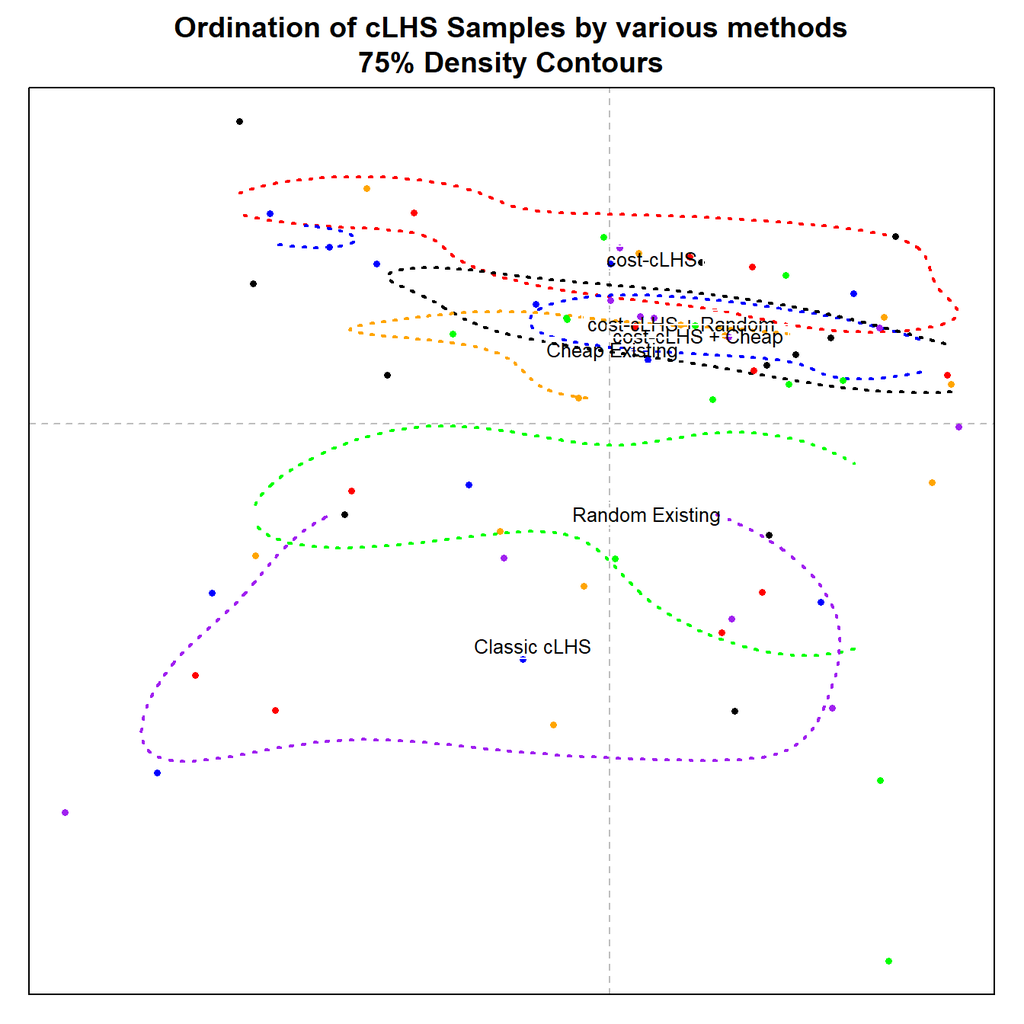

This *nMDS* graphic, though apparently complicated, corroborates the intuition we might have about the effects of including existing, non-optimal data.

We *omitted the cost raster from the ordination routine*, so that the separations we are seeing are due to true variation in the environment interaction with the different algorithms handling of cost.

If we consider the Classic cLHS to be the (in practice typically unachievable for Soil Survey) “gold standard”, then we can consider any offset from that Classic cLHS point cloud to be bias due to our method.

Is the Classic cLHS picking up on variation in the landscape that the cost-cLHS methods see as “too costly?”

*That is how I would interpret this graphic.*

The *cost-constrained* results are offset substantially on the vertical axis from the *Classic*.

This would suggest, as expected, that additional bias is introduced to cLHS by additional constraints on *Classic cLHS* method. The degree of bias in the existing data you force-include in *cost-constrained cLHS* will impact the deviation from the ideal. These differences seen in the nMDS may be essentially numerical noise – given the precision/accuracy of input raster data and the scaling that occurs during the nMDS process.

Future work will try to re-state differences in cLHS in more practical terms. Further, the `clhs()` code will be reviewed to determine if there is a better way to make use of the information in prior data.

**Food for thought:** Is the decrease in cost – i.e. making a project feasible v.s. not – sufficient to warrant increased bias?

*Should the cost raster be included in the ordination?*